# Visualización y exploración de datos

Última actualización:

17 de mayo de 2026

# Preparación

Necesitamos tener instalados los paquetes `ggplot2` y `qvalue` en R. En la carpeta de trabajo encontraréis también los datos necesarios.

Instalar paquetes con: install.packages(““)

# Objetivos

1. Practicar la representación gráfica de datos con `ggplot2`.
2. Aprender lo que es una gráfica volcán y una gráfica de Manhattan.
3. Demostrar que la exploración gráfica puede ayudarnos a comprender los datos.

# Datos

En esta sesión, trabajaremos con los resultados de un análisis de asociación genómica entre un fenotipo cuantitativo y los genotipos de 195 peces en 11746 posiciones variables o SNPs de su genoma. El archivo `gwas.txt` ha sido obtenido con el programa [PLINK2](https://www.cog-genomics.org/plink/2.0/) (Purcell et al. 2007; Chang et al. 2015). Contiene 16 columnas, descritas a continuación y también [en este enlace](https://www.cog-genomics.org/plink/2.0/formats#glm_linear):

- **CHROM**, **POS**, **ID**: cromosoma, posición e identificador del SNP.
- **REF**: alelo de referencia.
- **ALT**: alelo alternativo.
- **PROVISIONAL_REF.**: indica si el alelo de referencia es provisional o no.
- **A1**: alelo cuya dosis se usa en la regresión como variable independiente.
- **OMITTED**: el otro alelo.
- **A1_FREQ**: frecuencia del alelo A1 en la población.
- **TEST**: test estadístico aplicado. *ADD*: el efecto aditivo del alelo A1 es nulo.
- **OBS_CT**: tamaño muestral (número de individuos) en la regresión.
- **BETA**: coeficiente de regresión estimado para el alelo A1.
- **SE**: error estándar del coeficiente de regresión.
- **T_STAT**: estadístico *T*.
- **P**: valor *p* del estadístico.
- **ERRCODE**: código de error, si lo hay, o bien “.” (sin error).

Cargamos los datos en una sesión de R para empezar a explorarlos, y activamos el paquete `ggplot2`, que usaremos después.

```r
library('ggplot2')
gwas <- read.table('gwas.txt')
gwas <- gwas[! is.na(gwas$P),]
```

**NotaDesafío**

La orden `read.table('gwas.txt')` no da error, pero es errónea. ¿Puedes arreglarla?

```r
library('ggplot2')
gwas <- read.table('gwas.txt', header = TRUE)
gwas <- gwas[! is.na(gwas$P),]
```

Al ejecutar el archivo de gwas consigues una tabla donde la primera columna es el nombre del cromosoma y el resto de columnas muestran otras características. Como la orden que hemos dado de primeras era errónea, se añade el argumento header igual a true para que la primera fila la cuente como cabecera de la tabla y no como si fueran datos comunes.

# Comprobar las suposiciones

Sabemos que el estadístico *T* es la relación entre la diferencia del valor estimado de un parámetro ($\beta$) respecto su valor asumido (0) y el error estándar de la estimación. Comprobémoslo con `ggplot()`:

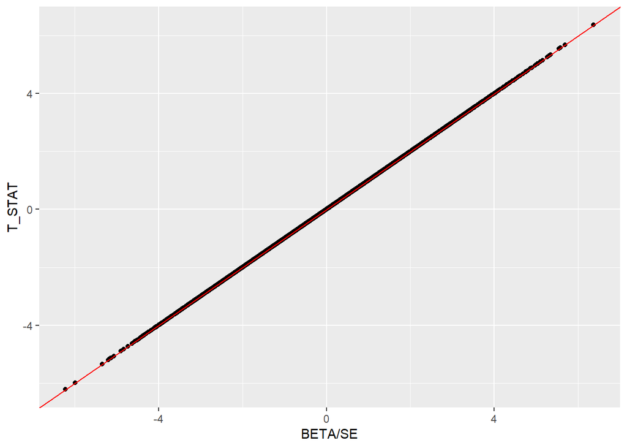

```r
ggplot(data = gwas,
       mapping = aes(x = BETA / SE, y = T_STAT)) +
   geom_point() +
   geom_abline(intercept = 0, slope = 1, color = 'red')
```

**NotaDesafío**

Comprueba gráficamente las suposiciones siguientes. Esfuérzate por imaginar qué forma esperas que adopte la gráfica en cada caso antes de representarla. Si en algún caso encuentras una relación diferente a la esperada, trata de explicarte por qué.

1. El valor *p* sólo depende del estadístico *T*.

2. El alelo A1 es siempre el que tiene la frecuencia más baja, en estos datos. Si el alelo A1 tuviera siempre la frecuencia más baja en todos los datos, todas sus frecuencias calculadas tendrían que ser estrictamente menores a 0.5. Esto se comprueba mediante un histograma, tal y como se demuestra en la gráfica de abajo al evaluar la distribución de la variable.

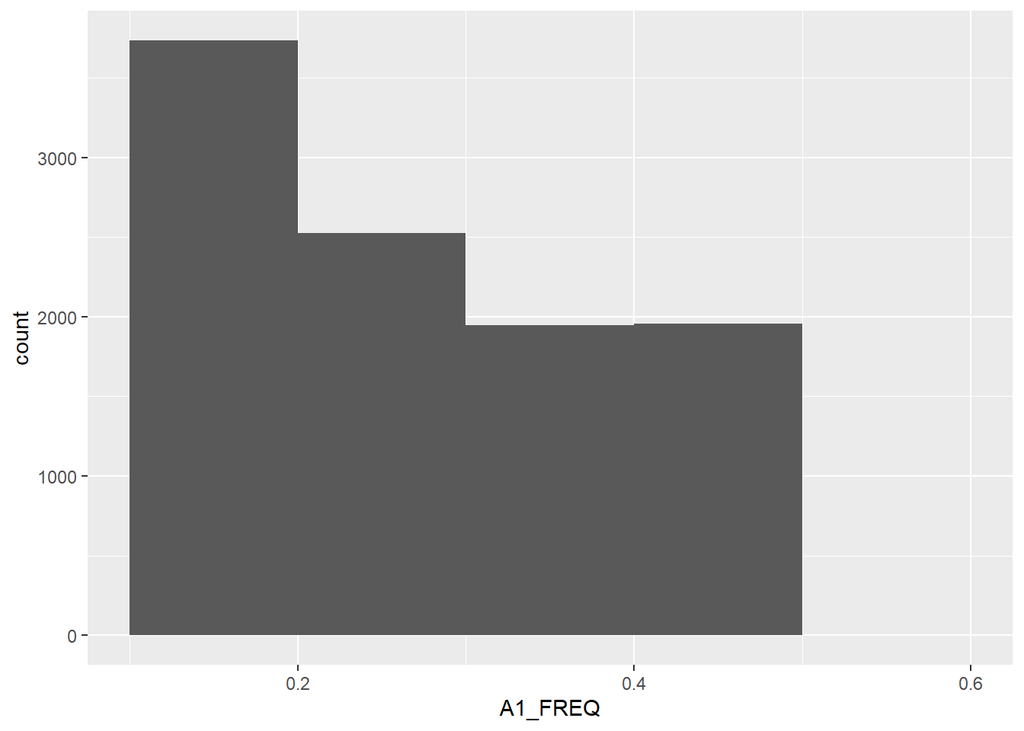

```r
ggplot(gwas, aes(x=A1_FREQ)) + geom_histogram(breaks=c(0.1,0.2,0.3,0.4,0.5,0.6))
```

3. El error estándar es menor cuanto mayor es el tamaño muestral.